# Script: MultiWeightedMaxLike

Michael Tiefelsdorf

3/29/2020

# 1 Read data & explore data

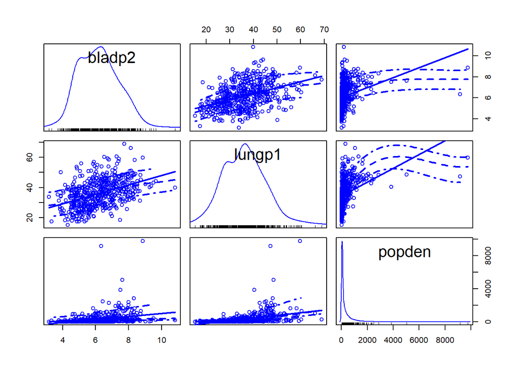

```r
> setwd("G:\\UTD_Classes\\2020Spring\\GISC7310_AdvancedDataAnalysis\\LC6MLandGLS")
> Bladder <- foreign::read.spss("bladder_wmp2.sav",to.data.frame=TRUE)
>
> car::scatterplotMatrix(~bladp2+lungp1+popden, data=Bladder)
```

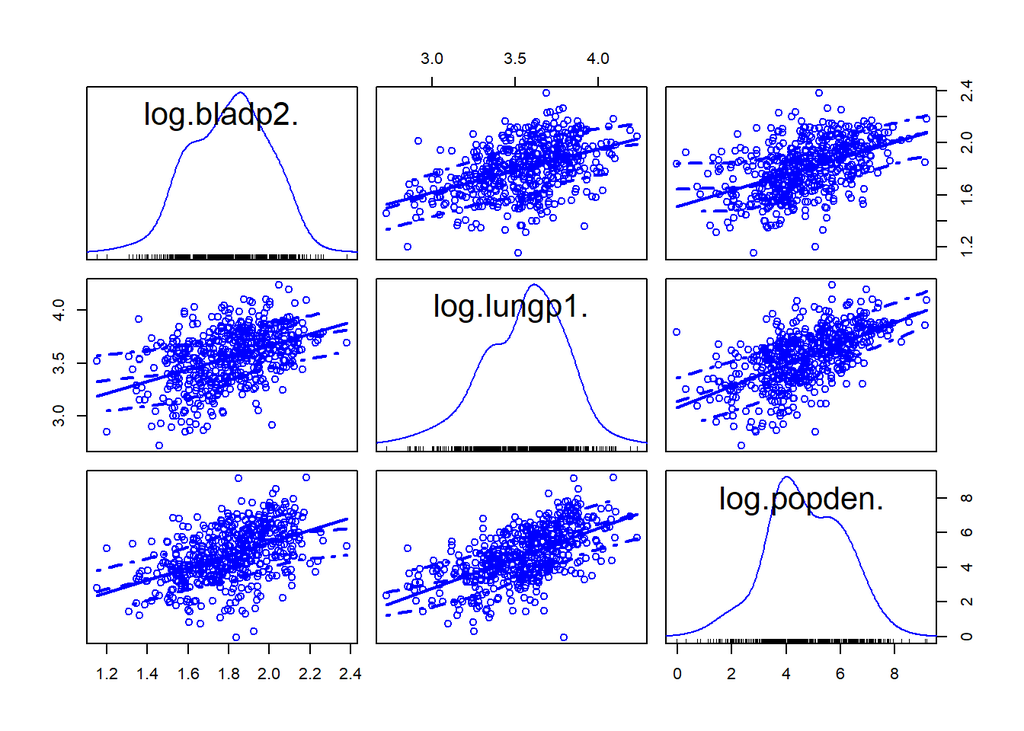

```r
> car::scatterplotMatrix(~log(bladp2)+log(lungp1)+log(popden), data=Bladder)
```

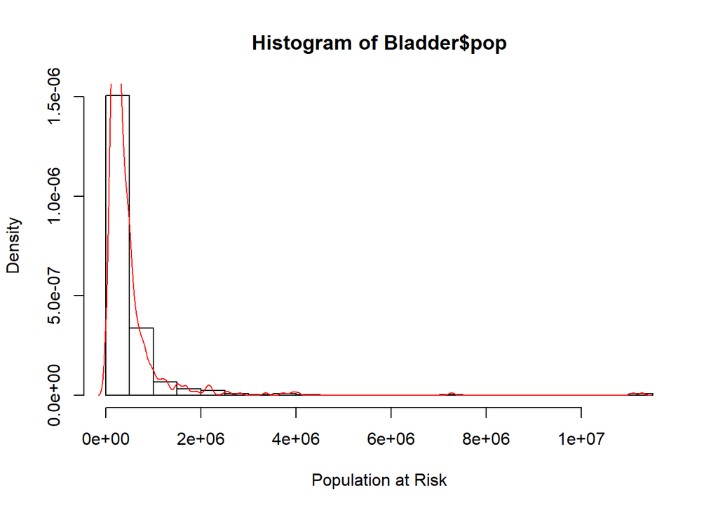

```r
> hist(Bladder$pop, breaks=20, freq=FALSE, xlab="Population at Risk")
> lines(density(Bladder$pop), col="red")
```

Note: these data are *areal aggregates* therefore there will be some *ecological biases* in the model estimates.

# 2 Variables description

- The dependent variable `bladp2` measure the age-adjusted male bladder cancer mortality rate per 100.000 population at risk for the 508 US State Economic Areas (SEA) for the period of 1970 to 1994.
- The independent variable `lungp1` is the male lung cancer rate for the period 1950 to 1969. It is a proxy variable for smoking. Smoking is both a risk factor for lung and bladder cancer. Lung cancer has a shorter latency period than bladder cancer. Therefore, the 1950 to 1969 period is used.
- The independent variable `popden` is a proxy variable for behavioral and environmental factors. The populations behavior as well as environmental conditions are different in urban, suburban and rural SEAs.
- The weights variable `pop` is the count of the population at risk in each SEA for the period 1970 to 1994. It varies substantially from SEA to SEA. Thus the SEA’s rates of `bladp2` have different denominators and are expected to have varying variances, which cause heteroscedasticity.

# 3 Basic model and heteroscedasticity test

```r
> lmBase <- lm(log(bladp2)~log(lungp1)+log(popden), data=Bladder)
> summary(lmBase)
```

```
R>
R> Call:
R> lm(formula = log(bladp2) ~ log(lungp1) + log(popden), data = Bladder)
R>
R> Residuals:
R>      Min       1Q   Median       3Q      Max
R> -0.56499 -0.11382  0.00918  0.11140  0.53233
R>
R> Coefficients:
R>             Estimate Std. Error t value Pr(>|t|)
R> (Intercept) 0.941258   0.115383   8.158 2.73e-15 ***
R> log(lungp1) 0.185532   0.036541   5.077 5.39e-07 ***
R> log(popden) 0.043155   0.006198   6.962 1.04e-11 ***
R> ---
R> Signif. codes:  0 '***' 0.001 '**' 0.01 '*' 0.05 '.' 0.1 ' ' 1
R>
R> Residual standard error: 0.1733 on 505 degrees of freedom
R> Multiple R-squared:  0.2595, Adjusted R-squared:  0.2566
R> F-statistic: 88.49 on 2 and 505 DF,  p-value: < 2.2e-16
```

```r
> car::ncvTest(lmBase, data=Bladder)
```

```
R> Non-constant Variance Score Test
R> Variance formula: ~ fitted.values
R> Chisquare = 3.732424, Df = 1, p = 0.053366
```

```r
> car::ncvTest(lmBase, var.formula=~log(pop), data=Bladder)
```

```
R> Non-constant Variance Score Test
R> Variance formula: ~ log(pop)
R> Chisquare = 16.21862, Df = 1, p = 5.6437e-05
```

Concurring with epidemiological knowledge, the higher the smoking rate (i.e., `lungp1`) the higher the bladder cancer rate. More densely populated SEA’s have are populated the higher the bladder cancer rate.

The Breusch-Pagan test `car::ncvTest` preforms a score test of the hypothesis of constant error variance against the alternatives [a] that the error variance changes with the level of the fitted values (first test), or [b] with a linear combination of predictors (second test). Notice that the weights variable in the second test is entered log-transformed.

- The unspecific test without an explicit heteroscedasticity model is borderline significant.
- In contrast, assuming that the error variance is a function of the underlying population at risk is highly significant.

# 4 Underlying idea of model calibration

See Kleiber & Zeileis pp 76-78 “Weighted Least Squares”. At the first step, use the model

$$\log{\hat{\sigma}_i^2}={\tt fitted}(\log{\epsilon_i^2} \sim \log pop_i)$$
to predict the heteroscedastic error variance. In a subsequent step use the inverse variance $w_i=\frac{1}{\exp(\hat{\sigma}_i^2)}$ as weight in an updated regression $y \sim x_1+x_2+ \cdots +x_k, {\tt weight}=w_i$. Note: This way observations with higher uncertainty are down-weighted. It is possible to iterate.

```r
> auxreg <- lm(log(residuals(lmBase)^2)~log(Bladder$pop))
> summary(auxreg)
```

```
R>
R> Call:
R> lm(formula = log(residuals(lmBase)^2) ~ log(Bladder$pop))
R>
R> Residuals:
R>      Min       1Q   Median       3Q      Max
R> -15.8322  -1.0073   0.4959   1.6622   3.7250
R>
R> Coefficients:
R>                  Estimate Std. Error t value Pr(>|t|)
R> (Intercept)        0.5011     1.5274   0.328 0.743005
R> log(Bladder$pop)  -0.4246     0.1207  -3.518 0.000474 ***
R> ---
R> Signif. codes:  0 '***' 0.001 '**' 0.01 '*' 0.05 '.' 0.1 ' ' 1
R>
R> Residual standard error: 2.358 on 506 degrees of freedom
R> Multiple R-squared:  0.02388,    Adjusted R-squared:  0.02195
R> F-statistic: 12.38 on 1 and 506 DF,  p-value: 0.0004738
```

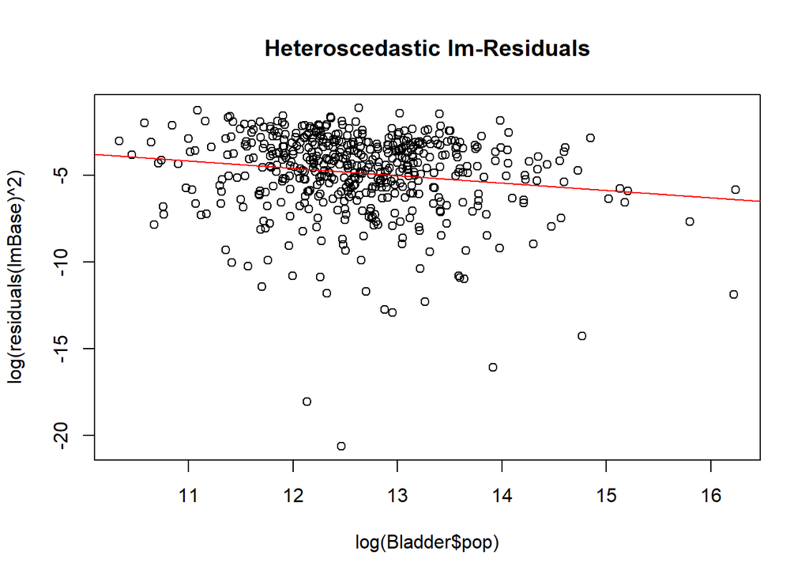

```r
> plot(log(residuals(lmBase)^2)~log(Bladder$pop)); abline(auxreg, col="red")
> title("Heteroscedastic lm-Residuals")
```

```r
> ## Weighted Regression
> predLogSigma2 <- fitted(auxreg)
> lmUpdated <- update(lmBase, weights=1/exp(predLogSigma2))
> summary(lmUpdated)
```

```
R>
R> Call:
R> lm(formula = log(bladp2) ~ log(lungp1) + log(popden), data = Bladder,
R>     weights = 1/exp(predLogSigma2))
R>
R> Weighted Residuals:
R>     Min      1Q  Median      3Q     Max
R> -6.4471 -1.2813  0.1356  1.2982  4.6998
R>
R> Coefficients:
R>             Estimate Std. Error t value Pr(>|t|)
R> (Intercept) 0.876799   0.113387   7.733 5.74e-14 ***
R> log(lungp1) 0.207043   0.035764   5.789 1.24e-08 ***
R> log(popden) 0.040045   0.005739   6.977 9.48e-12 ***
R> ---
R> Signif. codes:  0 '***' 0.001 '**' 0.01 '*' 0.05 '.' 0.1 ' ' 1
R>
R> Residual standard error: 1.932 on 505 degrees of freedom
R> Multiple R-squared:  0.292,  Adjusted R-squared:  0.2892
R> F-statistic: 104.1 on 2 and 505 DF,  p-value: < 2.2e-16
```

# 5 Use `lmHetero()` to model Heteroscedasticity

To account for heteroscedasticity related to `log(pop)` the `lmHetero` function in the package `TexMix` can be used. See its online help on how to call the function and what objects it returns.

```r
> lmH1 <- lmHetero(lnbladd~lnlung1+lnpopden | log(pop), data=Bladder)
> summary(lmH1)                         # coefficients of lmH1 and lmBase are similar
```

```
R>
R> ================================================================
R> Multiplicatively Weighted Heteroscedasticity ML-Regression Model
R> ================================================================
R>
R> Call:
R> lmHetero(formula = lnbladd ~ lnlung1 + lnpopden | log(pop), data = Bladder)
R>
R> Regression Coefficients:
R>              Estimate   Std.Err z-value  Pr(>|z|)
R> (Intercept) 0.8895147 0.1133274  7.8491 4.219e-15 ***
R> lnlung1     0.2027807 0.0357727  5.6686 1.440e-08 ***
R> lnpopden    0.0406583 0.0058077  7.0007 2.547e-12 ***
R> ---
R> Signif. codes:  0 '***' 0.001 '**' 0.01 '*' 0.05 '.' 0.1 ' ' 1
R>
R> Gamma Coefficients:
R>                 Gamma   Std.Err z-value  Pr(>|z|)
R> (Intercept)  0.866053  0.916155  0.9453    0.3445
R> log(pop)    -0.349758  0.072383 -4.8321 1.351e-06 ***
R> ---
R> Signif. codes:  0 '***' 0.001 '**' 0.01 '*' 0.05 '.' 0.1 ' ' 1
R>
R> log-likelihood = 181.0003
R>
R> Heteroscedasticity likelihood ratio test:
R>        LR   df  Pr(Chi > LR)
R>  19.62507    1  9.422455e-06
```

```r
> names(lmH1)
```

```
R>  [1] "CALL"       "sigma2"     "gamma"      "namesGamma" "beta"
R>  [6] "weights"    "covBeta"    "covGamma"   "logLikeH1"  "logLikeH0"
```

Compared to the OLS model the estimated regression coefficients have not changed substantially because even under heteroscedasticity the OLS coefficients are unbiased. However, their standard errors will change.

The `gamma coefficient` of `log(pop)` is *negative* and significant. Thus with an increasing population at risk $n_i$, as suggested by theory, the error variance $\sigma_i^2$ shrinks:
$$\sigma_i^2 \sim \frac{1}{n_i}$$
The likelihood ratio test indicates that, compared to the log-likelihood of the plain OLS model, the log-likelihood of the adjusted model is *significantly* larger.

The `lmHetero( )` returns also a vector of case weights, which can be use in the standard `lm( )` function. This allows to perform the standard model diagnostics of the OLS model. The estimated regression coefficients are identical to those of the `lmHetero` model. The residuals obtained with the function `weighted.residuals( )` are free of heteroscedasticity with respect to the weights variable.

```r
> ## Once weights are estimated, diagnositcs could proceed with lm() and the weights-option
> wlm1 <- lm(log(bladp2)~log(lungp1)+log(popden), data=Bladder, weights=lmH1$weights)
> summary(wlm1)                         # Results of lmH1 and wlm1 are identical
```

```
R>
R> Call:
R> lm(formula = log(bladp2) ~ log(lungp1) + log(popden), data = Bladder,
R>     weights = lmH1$weights)
R>
R> Weighted Residuals:
R>     Min      1Q  Median      3Q     Max
R> -3.3463 -0.6636  0.0677  0.6663  2.4707
R>
R> Coefficients:
R>             Estimate Std. Error t value Pr(>|t|)
R> (Intercept) 0.889518   0.113664   7.826 2.98e-14 ***
R> log(lungp1) 0.202780   0.035879   5.652 2.66e-08 ***
R> log(popden) 0.040658   0.005825   6.980 9.32e-12 ***
R> ---
R> Signif. codes:  0 '***' 0.001 '**' 0.01 '*' 0.05 '.' 0.1 ' ' 1
R>
R> Residual standard error: 1.003 on 505 degrees of freedom
R> Multiple R-squared:  0.2854, Adjusted R-squared:  0.2826
R> F-statistic: 100.9 on 2 and 505 DF,  p-value: < 2.2e-16
```

```r
> wResid <- weighted.residuals(wlm1)    # Function to adjust residuals for heteroscedasticity
```

The example shows how a linear combination of several weights variables can be used.

```r
> ##
> ## Model with quadratic weights structure
> ##
> lmH2 <- lmHetero(log(bladp2)~log(lungp1)+log(popden) | log(pop)+I(log(pop)^2), data=Bladder)
> summary(lmH2)
```

```
R>
R> ================================================================
R> Multiplicatively Weighted Heteroscedasticity ML-Regression Model
R> ================================================================
R>
R> Call:
R> lmHetero(formula = log(bladp2) ~ log(lungp1) + log(popden) |
R>     log(pop) + I(log(pop)^2), data = Bladder)
R>
R> Regression Coefficients:
R>              Estimate   Std.Err z-value  Pr(>|z|)
R> (Intercept) 0.8839357 0.1138092  7.7668 7.994e-15 ***
R> log(lungp1) 0.2056273 0.0359429  5.7209 1.059e-08 ***
R> log(popden) 0.0396237 0.0055551  7.1328 9.832e-13 ***
R> ---
R> Signif. codes:  0 '***' 0.001 '**' 0.01 '*' 0.05 '.' 0.1 ' ' 1
R>
R> Gamma Coefficients:
R>                    Gamma    Std.Err z-value Pr(>|z|)
R> (Intercept)   -13.414521   8.002140 -1.6764  0.09367 .
R> log(pop)        1.902019   1.243728  1.5293  0.12619
R> I(log(pop)^2)  -0.088375   0.048245 -1.8318  0.06698 .
R> ---
R> Signif. codes:  0 '***' 0.001 '**' 0.01 '*' 0.05 '.' 0.1 ' ' 1
R>
R> log-likelihood = 182.1035
R>
R> Heteroscedasticity likelihood ratio test:
R>        LR   df  Pr(Chi > LR)
R>  21.83149    2   1.81699e-05
```

```r
> ##
> ## Manual LR-Test: Quadratic versus linear weights structue
> ##
> (chi <- -2*(lmH1$logLikeH1-lmH2$logLikeH1))
```

```
R> [1] 2.206415
```

```r
> (pchisq(chi,df=1, lower.tail=F))
```

```
R> [1] 0.1374377
```

The manual likelihood ratio test compares the model with `| log(pop)` against the augmented model `| log(pop)+I(log(pop)^2`. In this case, there is no significant improvement using the augmented model and its `Gamma Coefficients` are no longer significant.